# Benchmark de Ferramentas de Importação de Dados

Python, R e Julia: Velocidade vs. Facilidade de Uso

Diego Pires Silva, Henry Koiti Honda, Joaquim Bertoldi Nucci

## Motivação

- 📊 **Dados cada vez maiores**, notebooks com os mesmos 16GB RAM
- ⏳ Ferramentas clássicas (Pandas, R Base) sofrem com arquivos grandes
- 💡 **Polars e Parquet**: são realmente a solução?
- 🎯 Objetivo: testar na prática, sem nuvem cara ou NASA hardware

## Metodologia Experimental

**Hardware** - MSI Cyborg 14 (i7, RTX 4050, 16GB RAM) - Windows 11, modo “Alta Performance” - Processos concorrentes encerrados

**Protocolo** - 10 execuções por cenário - Mediana dos tempos (evita outliers) - 338 amostras totais

**Datasets** - **Giga**: NYC Taxi (estresse de RAM) - **Long**: NYC Taxi (processamento vetorial) - **Wide**: Stack Overflow Survey (muitas colunas)

**Tecnologias** - Python 3.13: Polars 1.33, Pandas 2.2 - R 4.4.3: readr 2.1.5, arrow 21.0 - Julia 1.2.0

## Resultado 1: CSV vs Parquet - Speedup

```r
df_41 <- df %>%
  filter(Cenario == '1_Leitura_Pura')

# Tabela de speedup
tabela <- df_41 %>%
  group_by(Dataset, Biblioteca, Formato) %>%
  summarise(Tempo = mean(Tempo_Segundos), .groups = "drop") %>%
  tidyr::pivot_wider(names_from = Formato, values_from = Tempo) %>%
  mutate(Speedup_X = round(CSV / Parquet, 2))

cat("\n🏆 Calculando ganhos de CSV → Parquet...\n")
```

```
🏆 Calculando ganhos de CSV → Parquet...
```

## Resultado 1: Tabela Completa de Speedup

```
              Dataset Biblioteca    CSV Parquet Speedup_X
1         Giga_Yellow      Julia 177.13    8.23     21.52
2         Giga_Yellow     Pandas 201.79   12.16     16.60
3         Giga_Yellow     Polars  51.23    9.41      5.44
4  StackOverflow_Wide     R_Base   2.08    0.21     10.02
5  StackOverflow_Wide     Polars   0.49    0.06      8.76
6  StackOverflow_Wide     Pandas   1.06    0.13      8.15
7  StackOverflow_Wide    R_Readr   1.68    0.22      7.77
8  StackOverflow_Wide      Julia   3.65    0.69      5.27
9         Yellow_Long      Julia  14.48    0.51     28.18
10        Yellow_Long     R_Base  13.39    0.53     25.03
11        Yellow_Long    R_Readr  12.53    0.55     22.98
12        Yellow_Long     Polars   0.55    0.16      3.44
13        Yellow_Long     Pandas   3.48    1.19      2.92
```

## Visualização: Parquet Destrói CSV

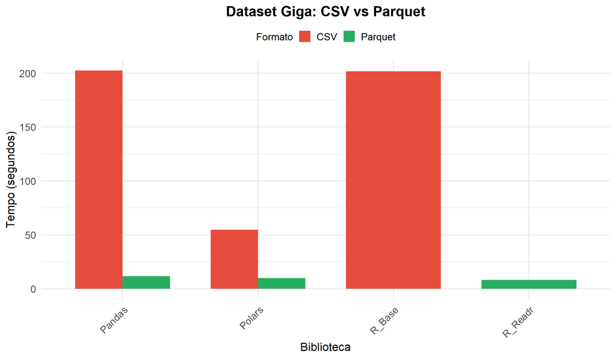

1. **Arquitetura JIT (Just-in-Time)**: Compila código em tempo de execução para velocidade nativa
2. **I/O Otimizado**: Engine especializada para leitura binária estruturada
3. **Gestão de Memória**: 20% mais eficiente que Pandas (~10GB vs 12GB)

**💡 Quando usar Julia:** - Pipelines recorrentes (JIT se paga após primeira execução) - Dados já em Parquet - Performance máxima é crítica

## Resultado 2: Ranking de Velocidade

```r
df_giga_rank <- df %>%
  filter(Dataset == 'Giga_Yellow', Cenario == '1_Leitura_Pura') %>%
  group_by(Formato, Biblioteca) %>%
  summarise(
    Tempo_s = median(Tempo_Segundos),
    RAM_GB = max(RAM_Pico_GB),
    .groups = "drop"
  )

cat("\n🥇 Calculando rankings...\n")
```

```
🥇 Calculando rankings...
```

## Ranking CSV (Força Bruta)

```
  Biblioteca Tempo_Mediano_s RAM_Pico_GB X_Vezes_Mais_Lento
1     Polars           54.82       15.71               1.00
2      Julia          164.52    15706.00               3.00
3     R_Base          201.72    15709.00               3.68
4     Pandas          202.37    15709.00               3.69
```

## Ranking Parquet (I/O Otimizado)

```
  Biblioteca Tempo_Mediano_s RAM_Pico_GB X_Vezes_Mais_Lento
1    R_Readr            8.27    15705.00               1.00
2      Julia            8.45     7373.00               1.02
3     Polars            9.85       15.71               1.19
4     Pandas           11.68    15709.00               1.41
```

## Resultado 3: Memória é o Limite

```r
df_mem <- df %>%
  filter(
    Cenario == '1_Leitura_Pura',
    Formato == 'CSV',
    Dataset %in% c('Yellow_Long', 'Giga_Yellow')
  ) %>%
  group_by(Dataset, Biblioteca) %>%
  summarise(
    RAM_GB = max(RAM_Pico_GB),
    Tempo_s = median(Tempo_Segundos),
    .groups = "drop"
  )

cat("\n💾 Calculando consumo de RAM...\n")
```

```
💾 Calculando consumo de RAM...
```

## Consumo de RAM (CSV)

```
  Biblioteca Giga_Yellow Yellow_Long
1      Julia    15706.00       10227
2     Pandas    15709.00       12828
3     Polars       15.71       14466
4     R_Base    15709.00        9012
5    R_Readr         NaN       10305
```

**⚠️ Todas atingiram ~15.7GB no Giga = Muro de hardware!**

## Resultado 4: Otimização Manual

```r
df_opt <- df %>%
  filter(Dataset == 'Yellow_Long', Formato == 'CSV')

tabela_opt <- df_opt %>%
  group_by(Biblioteca, Cenario) %>%
  summarise(Tempo = median(Tempo_Segundos), .groups = "drop") %>%
  tidyr::pivot_wider(names_from = Cenario, values_from = Tempo) %>%
  mutate(
    Ganho_Tipagem_Pct = round((1 - `2_Com_Tipagem` / `1_Leitura_Pura`) * 100, 1),
    Ganho_Colunas_Pct = round((1 - `3_Apenas_Colunas` / `1_Leitura_Pura`) * 100, 1)
  )

cat("\n⚙️ Calculando impacto de otimizações...\n")
```

```
⚙️ Calculando impacto de otimizações...
```

## Impacto de Otimizações

| Biblioteca | Base (s) | C/ Tipagem (s) | Ganho Tipagem (%) | Ganho Colunas (%) |
| --- | --- | --- | --- | --- |
| Pandas | 3.48 | 7.19 | -106.9 | 28.1 |
| Polars | 0.56 | 0.18 | 67.6 | 69.4 |
| R_Base | 13.32 | 8.88 | 33.3 | 2.9 |
| R_Readr | 12.43 | 8.49 | 31.7 | -0.9 |

**⚠️ Pandas com tipagem manual: -106% (piorou!)**

## Comparação Python vs R vs Julia

**🐍 Python (Polars)**

```python
import polars as pl
df = pl.read_csv("data.csv",
    columns=['col1', 'col2'])
```

✅ Campeão em CSV  
✅ Sintaxe moderna  
❌ Curva de aprendizado  
❌ Tipagem estrita

**📊 R (readr)**

```r
library(readr)
df <- read_csv("data.csv",
    col_select = c(col1, col2))
```

✅ Integração tidyverse  
✅ Sintaxe familiar  
✅ Parquet competitivo  
❌ CSV mais lento

**⚡ Julia**

```julia
using CSV, DataFrames
df = CSV.read("data.csv",
    DataFrame)
```

## Facilidade de Uso: Comparação de Código

- Pandas (Fácil)
- Polars (Rigoroso)
- R readr (Intuitivo)
- Julia (Performática)

```python
import pandas as pd

# Leitura simples, sem configuração
df = pd.read_csv("arquivo.csv")
print(df.head())

# Plug-and-play, mas pode ser lento
```

```python
import polars as pl

# Precisa configurar schema se houver problemas
df = pl.read_csv("arquivo.csv",
    schema_overrides={"col": pl.Int64})

# Rápido, mas exige atenção aos tipos
```

```r
library(readr)

# Sintaxe limpa, integração com pipes
df <- read_csv("arquivo.csv") %>%
  select(col1, col2)

# Familiar para usuários de R
```

```julia
using CSV, DataFrames

# Sintaxe simples, performance máxima
df = CSV.read("arquivo.csv", DataFrame)

# Melhor em Parquet, compilação inicial
```

## Guia Prático de Decisão (1/2)

[output not shown]

## Guia Prático de Decisão (2/2)

| Situação | Ferramenta Recomendada | Por quê? |
| --- | --- | --- |
| 🗂️ Parquet disponível | **Julia/Polars** | Julia: 8.2s, Polars: 9.4s (Giga) |
| 📊 Usuário de R | **readr/arrow** | Nunca use `read.csv()` nativo |
| 💼 Produção profissional | **Polars + Parquet** | Máxima eficiência + tipagem |
| 🔬 Computação científica | **Julia** | JIT compilation, mas curva de aprendizado |

ME315 - Benchmark de Importação